# Airline Satisfaction Report

Jeffrey Fernandez, Jack Keaveny, and Alex Qiu

2024-12-15

# Abstract

This data given by an airline organization. The actual name of the company is not given due to various purposes.The dataset consists of the details of customers who have already flown with them. The feedback of the customers on various context and their flight data has been consolidated.

The main purpose of this dataset is to predict whether a future customer would be satisfied with their service given the details of the other parameters values. Also the airlines need to know on which aspect of the services offered by them have to be emphasized more to generate more satisfied customers.

## Variable Breakdown

- **satisfaction**: (Categorical) Indicates whether the customer was satisfied or dissatisfied with their flight experience.
- **Gender**: (Categorical) Gender of the customer (Male/Female).
- **Customer.Type**: (Categorical) Indicates whether the customer is a Loyal Customer or a Disloyal Customer.
- **Age**: (Numeric) Age of the customer in years.
- **Type.of.Travel**: (Categorical) Purpose of the travel (Business travel/Personal travel).
- **Class**: (Categorical) Travel class (Business/Eco/Eco Plus).
- **Flight.Distance**: (Numeric) Distance of the flight in miles.
- **Seat.comfort**: (Numeric) Rating of seat comfort on a scale (1 to 5).
- **Departure.Arrival.time.convenient**: (Numeric) Rating of convenience of departure/arrival time (1 to 5).
- **Food.and.drink**: (Numeric) Rating of food and drink quality on the flight (1 to 5).
- **Gate.location**: (Numeric) Rating of the gate location’s convenience (1 to 5).
- **Inflight.wifi.service**: (Numeric) Rating of the inflight Wi-Fi service quality (1 to 5).
- **Inflight.entertainment**: (Numeric) Rating of inflight entertainment options (1 to 5).
- **Online.support**: (Numeric) Rating of the airline’s online support (1 to 5).
- **Ease.of.Online.booking**: (Numeric) Rating of the ease of online booking process (1 to 5).
- **On.board.service**: (Numeric) Rating of onboard service quality (1 to 5).
- **Leg.room.service**: (Numeric) Rating of leg room space (1 to 5).
- **Baggage.handling**: (Numeric) Rating of baggage handling efficiency (1 to 5).
- **Checkin.service**: (Numeric) Rating of the check-in service (1 to 5).
- **Cleanliness**: (Numeric) Rating of the cleanliness of the airplane (1 to 5).
- **Online.boarding**: (Numeric) Rating of the online boarding process (1 to 5).
- **Departure.Delay.in.Minutes**: (Numeric) Duration of departure delay in minutes.
- **Arrival.Delay.in.Minutes**: (Numeric) Duration of arrival delay in minutes.

```r
# Load necessary libraries
library(tidyverse)
library(FactoMineR)
library(factoextra)
library(cluster)
library(caret)
library(readr)
library(ggplot2)
library(ggpubr)
library(corrplot)
library(psych)
library(dplyr)
library(gridExtra)

airline_data <- read.csv("C:/Users/Jack Keaveny/Downloads/airline_customer_satisfaction.csv")

# Count the number of NA values in each column
na_counts <- colSums(is.na(airline_data))

# Create a data frame for visualization
na_data <- data.frame(
  Column = names(na_counts),
  NA_Count = as.numeric(na_counts)
)

na_data
```

```
##                               Column NA_Count
## 1                       satisfaction        0
## 2                             Gender        0
## 3                      Customer.Type        0
## 4                                Age        0
## 5                     Type.of.Travel        0
## 6                              Class        0
## 7                    Flight.Distance        0
## 8                       Seat.comfort        0
## 9  Departure.Arrival.time.convenient        0
## 10                    Food.and.drink        0
## 11                     Gate.location        0
## 12             Inflight.wifi.service        0
## 13            Inflight.entertainment        0
## 14                    Online.support        0
## 15            Ease.of.Online.booking        0
## 16                  On.board.service        0
## 17                  Leg.room.service        0
## 18                  Baggage.handling        0
## 19                   Checkin.service        0
## 20                       Cleanliness        0
## 21                   Online.boarding        0
## 22        Departure.Delay.in.Minutes        0
## 23          Arrival.Delay.in.Minutes        0
```

```r
airline_data$satisfaction <- factor(
  airline_data$satisfaction,
  levels = c("satisfied", "dissatisfied") # Specify the desired order
)
```

No Na Data, No major Cleaning needed, all columns hold value to some degree, satisfaction factores for ease of graphing.

# Descriptive Analytics

## 1) Distribution of Satisfaction By age?

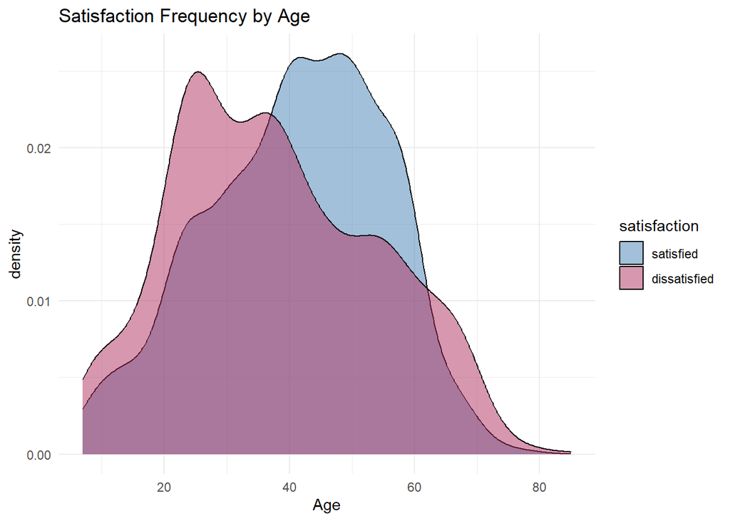

```r
ggplot(airline_data, aes(Age, fill = satisfaction)) +
  geom_density(alpha = 0.5) +
  labs(title = "Satisfaction Frequency by Age",
       x = "Age")+
  scale_fill_manual(
    values = c("satisfied" = "steelblue", "dissatisfied" = "maroon") # Custom colors
  ) +
  theme_minimal()
```

## 2) - How does satisfaction vary by gender, travel class, or customer type?

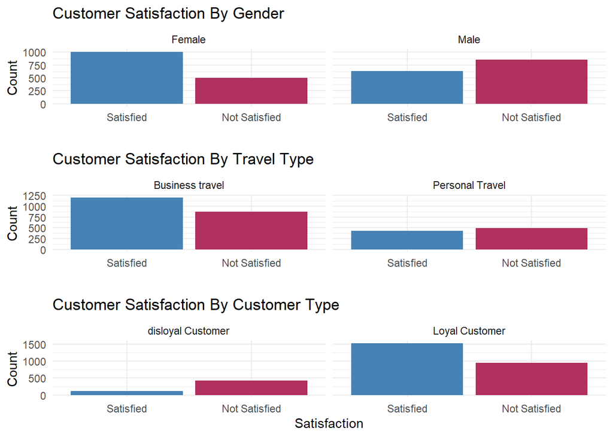

```r
p1 = ggplot(airline_data, aes(x = satisfaction, fill = satisfaction)) +
  geom_bar() +
  labs( x= "", y = "Count") +
  scale_x_discrete(labels = c("Satisfied", "Not Satisfied")) +
  scale_fill_manual(
    values = c("satisfied" = "steelblue", "dissatisfied" = "maroon") # Set custom colors
  ) +
  ggtitle("Customer Satisfaction By Gender") +
  theme_minimal() +
  theme(legend.position = "none")+
  facet_wrap(~ Gender)

p2 = ggplot(airline_data, aes(x = factor(satisfaction), fill = factor(satisfaction))) +
  geom_bar() +
  labs(x= "", y = "Count", fill = "Satisfaction") +
  scale_x_discrete(labels = c("Satisfied", "Not Satisfied")) +
  scale_fill_manual(
    values = c("satisfied" = "steelblue", "dissatisfied" = "maroon") # Set custom colors
  ) +
  ggtitle("Customer Satisfaction By Travel Type") +
  theme_minimal() +
  theme(legend.position = "none")+
  facet_wrap(~ Type.of.Travel)

p3 = ggplot(airline_data, aes(x = factor(satisfaction), fill = factor(satisfaction))) +
  geom_bar() +
  labs(x = "Satisfaction", y = "Count", fill = "Satisfaction") +
  scale_x_discrete(labels = c("Satisfied", "Not Satisfied")) +
  scale_fill_manual(
    values = c("satisfied" = "steelblue", "dissatisfied" = "maroon") # Set custom colors
  ) +
  ggtitle("Customer Satisfaction By Customer Type") +
  theme_minimal() +
  theme(legend.position = "none")+
  facet_wrap(~ Customer.Type)

grid.arrange(p1, p2, p3,  nrow = 3)
```

## 3) - What percentage of customers are classified as satisfied or dissatisfied?

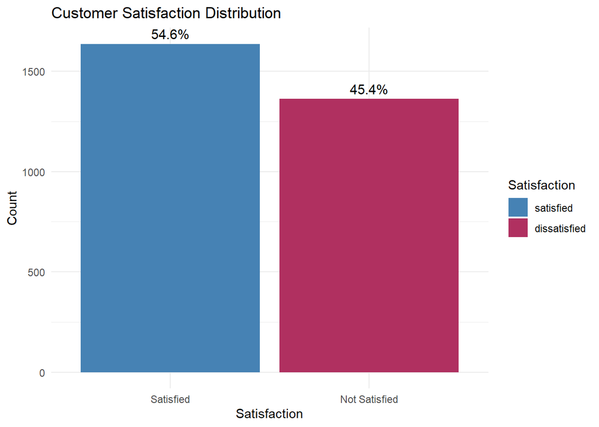

```r
satisfaction_counts <- airline_data %>%
  group_by(satisfaction) %>%
  summarise(Count = n()) %>%
  mutate(Percentage = Count / sum(Count) * 100)



# Plot with percentage labels
ggplot(satisfaction_counts, aes(x = factor(satisfaction), y = Count, fill = factor(satisfaction))) +
  geom_bar(stat = "identity") +
  geom_text(aes(label = paste0(round(Percentage, 1), "%")), vjust = -0.5, size = 4) + # Add percentage labels
  labs(
    x = "Satisfaction",
    y = "Count",
    fill = "Satisfaction",
    title = "Customer Satisfaction Distribution"
  ) +
  scale_x_discrete(labels = c("Satisfied", "Not Satisfied")) +
  scale_fill_manual(
    values = c("satisfied" = "steelblue", "dissatisfied" = "maroon") # Set custom colors
  ) +
  theme_minimal()
```

## 4) - Which services have the highest and lowest ratings?

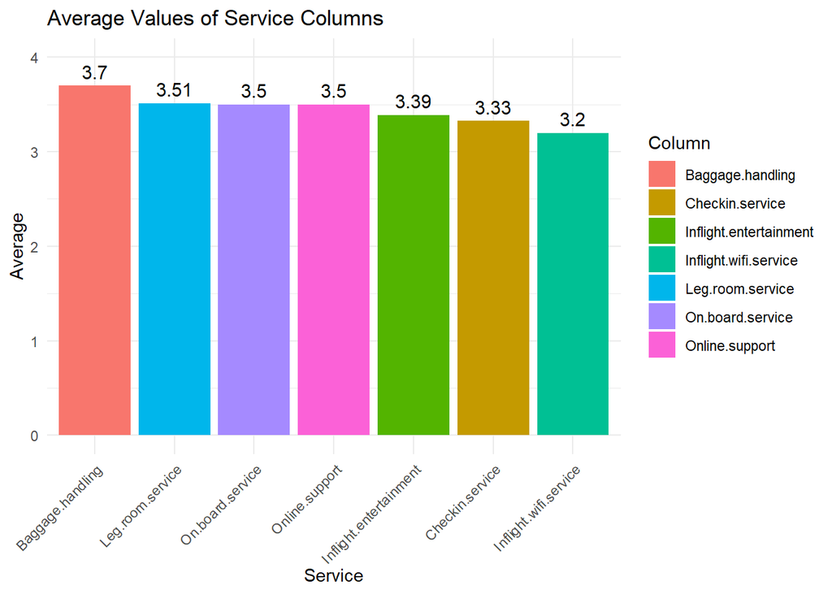

```r
# 2. Which services have the highest and lowest ratings?
service_ratings = colMeans(airline_data[, c("Inflight.wifi.service", "Inflight.entertainment", "Online.support", "On.board.service", "Leg.room.service", "Checkin.service", "Baggage.handling")], na.rm = TRUE)

avg_data <- data.frame(
  Column = names(service_ratings),
  Average = as.numeric(service_ratings)
)

ggplot(avg_data, aes(x = reorder(Column, -Average), y = Average, fill = Column)) +
  geom_bar(stat = "identity") +
  labs(
    title = "Average Values of Service Columns",
    x = "Service",
    y = "Average"
  ) +
  geom_text(aes(label = round(Average, 2)), vjust = -0.5, size = 4) +
  ylim(0, 4) +
  theme_minimal() +
  theme(axis.text.x = element_text(angle = 45, hjust = 1))
```

Highest Service Rating for the Airline is **Baggage Handling** with a score of 3.7 and the lowest is **Inflight Wifi** with 3.2. With only a .5 spread of average ratings amongst all service columns we can see the airline is fairly consistent in their reviews.

# Exploratory Analytics/PCA

## 4) Which variables are most correlated with overall satisfaction?

```r
# check numeric variables
numeric_cols = airline_data[, sapply(airline_data, is.numeric)]

filtered_data <- numeric_cols%>%
  dplyr::select(-Age, -Flight.Distance, -Departure.Delay.in.Minutes, -Arrival.Delay.in.Minutes)

str(filtered_data)
```

```
## 'data.frame':    3000 obs. of  14 variables:
##  $ Seat.comfort                     : int  3 2 3 4 4 4 1 5 2 0 ...
##  $ Departure.Arrival.time.convenient: int  5 5 3 3 4 4 4 5 4 5 ...
##  $ Food.and.drink                   : int  5 5 3 3 4 4 1 5 2 0 ...
##  $ Gate.location                    : int  5 5 3 3 4 2 4 5 4 1 ...
##  $ Inflight.wifi.service            : int  2 2 5 4 5 4 3 3 2 1 ...
##  $ Inflight.entertainment           : int  4 2 5 4 4 5 1 5 2 0 ...
##  $ Online.support                   : int  3 2 5 4 4 5 4 5 1 1 ...
##  $ Ease.of.Online.booking           : int  3 2 3 4 4 3 3 4 2 1 ...
##  $ On.board.service                 : int  3 1 3 4 4 3 4 4 4 3 ...
##  $ Leg.room.service                 : int  3 5 3 1 5 4 5 5 3 4 ...
##  $ Baggage.handling                 : int  3 1 3 5 4 3 5 4 4 4 ...
##  $ Checkin.service                  : int  4 5 4 1 3 4 4 5 4 3 ...
##  $ Cleanliness                      : int  3 3 3 1 4 3 4 4 5 5 ...
##  $ Online.boarding                  : int  3 2 4 4 3 4 3 5 2 1 ...
```

```r
#  standardize  data
standardized_data = scale(filtered_data)

# Perform PCA
pca = PCA(standardized_data, graph = FALSE)
summary(pca)
```

```
##
## Call:
## PCA(X = standardized_data, graph = FALSE)
##
##
## Eigenvalues
##                        Dim.1   Dim.2   Dim.3   Dim.4   Dim.5   Dim.6   Dim.7
## Variance               3.875   2.565   2.135   1.022   0.878   0.655   0.506
## % of var.             27.682  18.323  15.250   7.297   6.274   4.676   3.613
## Cumulative % of var.  27.682  46.004  61.254  68.551  74.825  79.501  83.114
##                        Dim.8   Dim.9  Dim.10  Dim.11  Dim.12  Dim.13  Dim.14
## Variance               0.470   0.449   0.371   0.346   0.289   0.240   0.200
## % of var.              3.354   3.209   2.649   2.475   2.063   1.711   1.425
## Cumulative % of var.  86.468  89.677  92.327  94.801  96.864  98.575 100.000
##
## Individuals (the 10 first)
##                                       Dist    Dim.1    ctr   cos2    Dim.2
## 1                                 |  3.080 | -0.386  0.001  0.016 |  2.639
## 2                                 |  5.061 | -2.242  0.043  0.196 |  2.677
## 3                                 |  2.547 |  0.813  0.006  0.102 |  0.266
## 4                                 |  4.069 | -0.007  0.000  0.000 |  0.746
## 5                                 |  2.593 |  1.702  0.025  0.430 |  1.167
## 6                                 |  2.715 |  1.061  0.010  0.153 |  0.882
## 7                                 |  3.369 | -0.169  0.000  0.003 | -1.047
## 8                                 |  4.168 |  2.973  0.076  0.509 |  2.363
## 9                                 |  3.404 | -1.648  0.023  0.234 |  0.320
## 10                                |  5.792 | -3.742  0.120  0.417 | -1.663
##                                      ctr   cos2    Dim.3    ctr   cos2
## 1                                  0.090  0.734 |  0.018  0.000  0.000 |
## 2                                  0.093  0.280 |  0.149  0.000  0.001 |
## 3                                  0.001  0.011 | -1.963  0.060  0.594 |
## 4                                  0.007  0.034 | -1.832  0.052  0.203 |
## 5                                  0.018  0.203 |  0.181  0.001  0.005 |
## 6                                  0.010  0.105 | -1.358  0.029  0.250 |
## 7                                  0.014  0.097 |  1.507  0.035  0.200 |
## 8                                  0.073  0.321 |  0.100  0.000  0.001 |
## 9                                  0.001  0.009 |  2.299  0.083  0.456 |
## 10                                 0.036  0.082 |  2.980  0.139  0.265 |
##
## Variables (the 10 first)
##                                      Dim.1    ctr   cos2    Dim.2    ctr   cos2
## Seat.comfort                      |  0.429  4.743  0.184 |  0.716 19.971  0.512
## Departure.Arrival.time.convenient |  0.225  1.309  0.051 |  0.713 19.807  0.508
## Food.and.drink                    |  0.314  2.542  0.099 |  0.833 27.069  0.694
## Gate.location                     |  0.144  0.535  0.021 |  0.742 21.440  0.550
## Inflight.wifi.service             |  0.588  8.915  0.346 | -0.121  0.569  0.015
## Inflight.entertainment            |  0.575  8.540  0.331 |  0.147  0.842  0.022
## Online.support                    |  0.678 11.847  0.459 | -0.165  1.066  0.027
## Ease.of.Online.booking            |  0.837 18.072  0.700 | -0.229  2.050  0.053
## On.board.service                  |  0.565  8.223  0.319 | -0.196  1.501  0.039
## Leg.room.service                  |  0.461  5.481  0.212 | -0.139  0.749  0.019
##                                      Dim.3    ctr   cos2
## Seat.comfort                      |  0.012  0.007  0.000 |
## Departure.Arrival.time.convenient |  0.151  1.071  0.023 |
## Food.and.drink                    |  0.051  0.121  0.003 |
## Gate.location                     |  0.056  0.149  0.003 |
## Inflight.wifi.service             | -0.543 13.809  0.295 |
## Inflight.entertainment            | -0.230  2.485  0.053 |
## Online.support                    | -0.488 11.162  0.238 |
## Ease.of.Online.booking            | -0.138  0.889  0.019 |
## On.board.service                  |  0.521 12.718  0.272 |
## Leg.room.service                  |  0.478 10.687  0.228 |
```

```r
# Eigenvalues
eigenvalues = get_eigenvalue(pca)
print(eigenvalues)
```

```
##        eigenvalue variance.percent cumulative.variance.percent
## Dim.1   3.8754396        27.681712                    27.68171
## Dim.2   2.5651764        18.322689                    46.00440
## Dim.3   2.1349881        15.249915                    61.25432
## Dim.4   1.0215618         7.296870                    68.55119
## Dim.5   0.8783078         6.273627                    74.82481
## Dim.6   0.6547007         4.676433                    79.50125
## Dim.7   0.5058494         3.613210                    83.11446
## Dim.8   0.4695098         3.353642                    86.46810
## Dim.9   0.4492894         3.209210                    89.67731
## Dim.10  0.3709157         2.649398                    92.32671
## Dim.11  0.3464352         2.474537                    94.80124
## Dim.12  0.2887745         2.062675                    96.86392
## Dim.13  0.2395421         1.711015                    98.57493
## Dim.14  0.1995093         1.425067                   100.00000
```

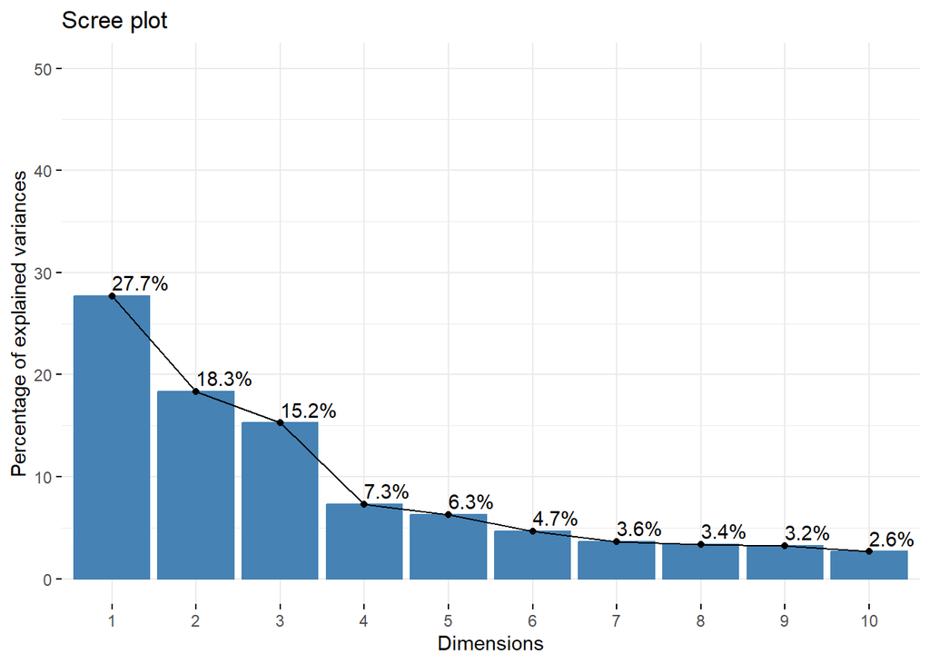

```r
# Scree Plot
fviz_eig(pca, addlabels = TRUE, ylim = c(0, 50))
```

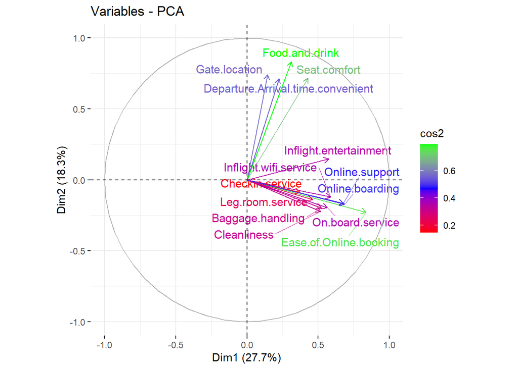

```r
# Variable contributions to pca
fviz_pca_var(pca, col.var = "cos2", gradient.cols = c("red", "blue", "green"), repel = TRUE)
```

```r
# PCA variable contributions
var = get_pca_var(pca)
head(var$coord)
```

```
##                                       Dim.1      Dim.2       Dim.3      Dim.4
## Seat.comfort                      0.4287138  0.7157379  0.01197906  0.1612639
## Departure.Arrival.time.convenient 0.2252136  0.7127950  0.15121738 -0.2143876
## Food.and.drink                    0.3138935  0.8332855  0.05076194  0.1197201
## Gate.location                     0.1440499  0.7416005  0.05643451 -0.3453659
## Inflight.wifi.service             0.5877981 -0.1207650 -0.54296672 -0.2401971
## Inflight.entertainment            0.5752970  0.1469741 -0.23034103  0.5834601
##                                         Dim.5
## Seat.comfort                      -0.25342217
## Departure.Arrival.time.convenient  0.31051207
## Food.and.drink                    -0.16160111
## Gate.location                      0.24118774
## Inflight.wifi.service              0.03985234
## Inflight.entertainment            -0.29312625
```

```r
head(var$contrib)
```

```
##                                       Dim.1     Dim.2        Dim.3     Dim.4
## Seat.comfort                      4.7425717 19.970584  0.006721254  2.545715
## Departure.Arrival.time.convenient 1.3087848 19.806696  1.071045538  4.499194
## Food.and.drink                    2.5423993 27.068885  0.120692705  1.403037
## Gate.location                     0.5354331 21.439900  0.149174296 11.676002
## Inflight.wifi.service             8.9152866  0.568545 13.808641426  5.647692
## Inflight.entertainment            8.5401049  0.842101  2.485118817 33.324038
##                                       Dim.5
## Seat.comfort                       7.312106
## Departure.Arrival.time.convenient 10.977672
## Food.and.drink                     2.973322
## Gate.location                      6.623137
## Inflight.wifi.service              0.180826
## Inflight.entertainment             9.782789
```

```r
head(var$cos2)
```

```
##                                        Dim.1      Dim.2       Dim.3      Dim.4
## Seat.comfort                      0.18379551 0.51228072 0.000143498 0.02600606
## Departure.Arrival.time.convenient 0.05072116 0.50807670 0.022866695 0.04596205
## Food.and.drink                    0.09852915 0.69436466 0.002576775 0.01433289
## Gate.location                     0.02075038 0.54997126 0.003184854 0.11927757
## Inflight.wifi.service             0.34550655 0.01458418 0.294812857 0.05769466
## Inflight.entertainment            0.33096661 0.02160138 0.053056992 0.34042564
##                                         Dim.5
## Seat.comfort                      0.064222797
## Departure.Arrival.time.convenient 0.096417747
## Food.and.drink                    0.026114918
## Gate.location                     0.058171525
## Inflight.wifi.service             0.001588209
## Inflight.entertainment            0.085922998
```

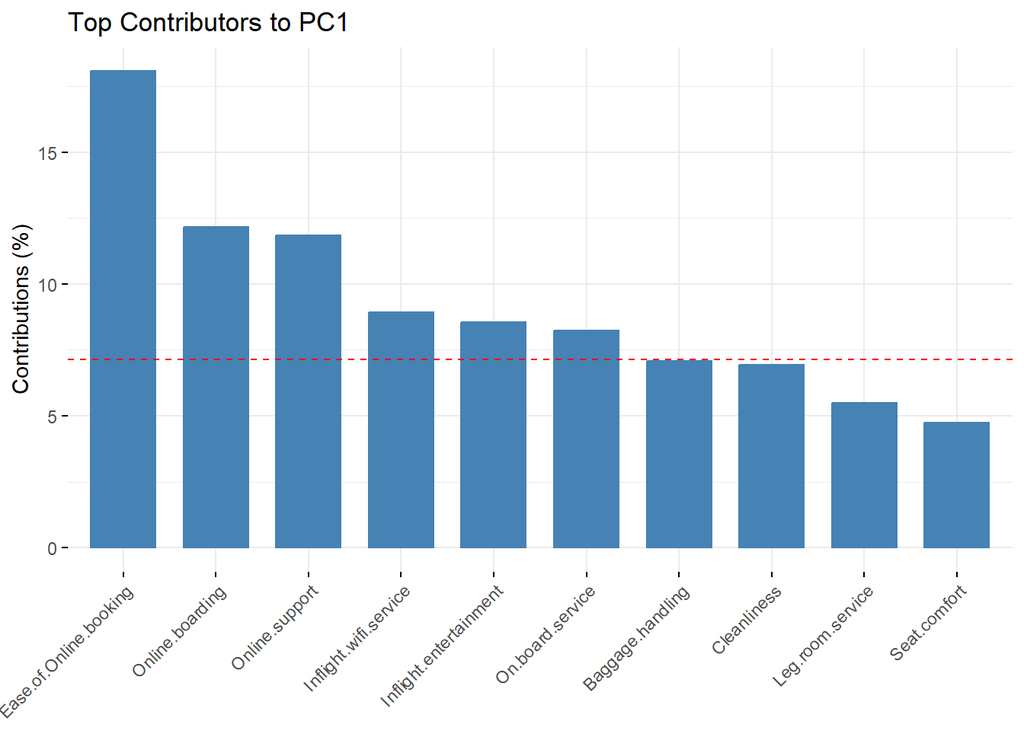

```r
# Top contributors to PC1 and PC2
fviz_contrib(pca, choice = "var", axes = 1, top = 10) + ggtitle("Top Contributors to PC1")
```

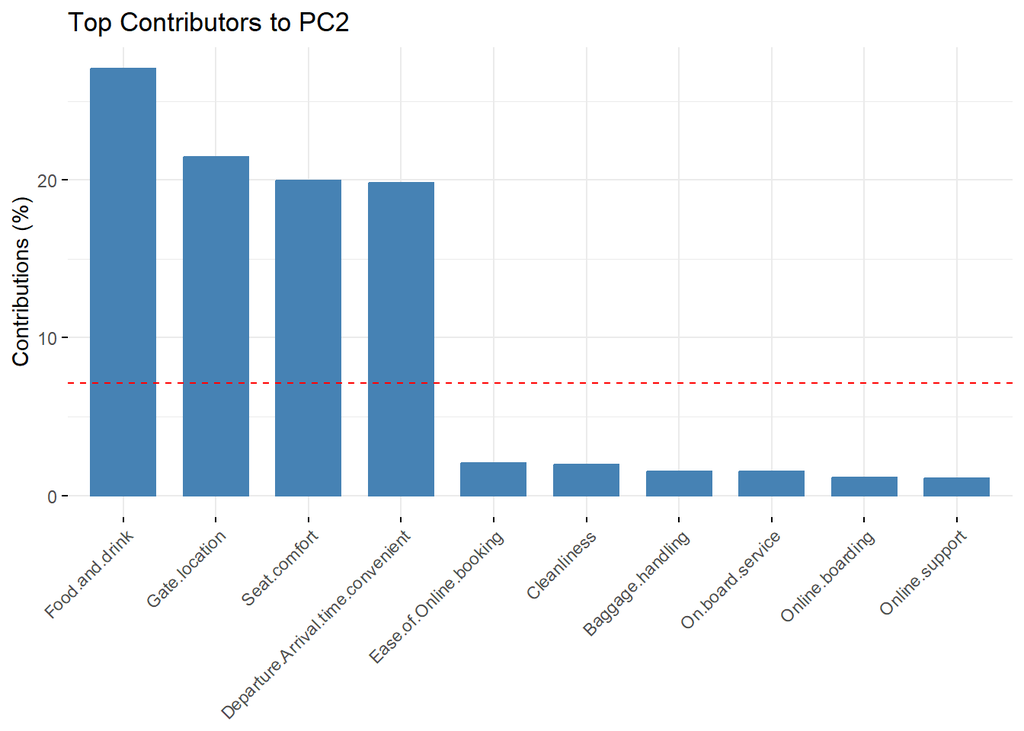

```r
fviz_contrib(pca, choice = "var", axes = 2, top = 10) + ggtitle("Top Contributors to PC2")
```

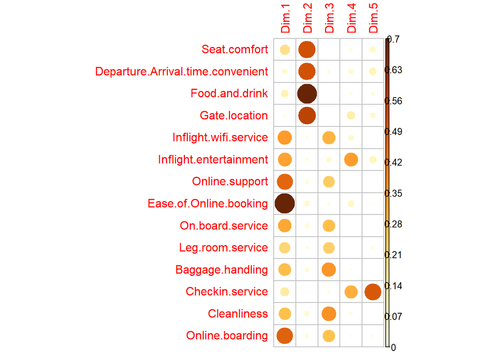

```r
# Correlation Plot of cos2 values
corrplot(var$cos2, is.corr = FALSE)
```

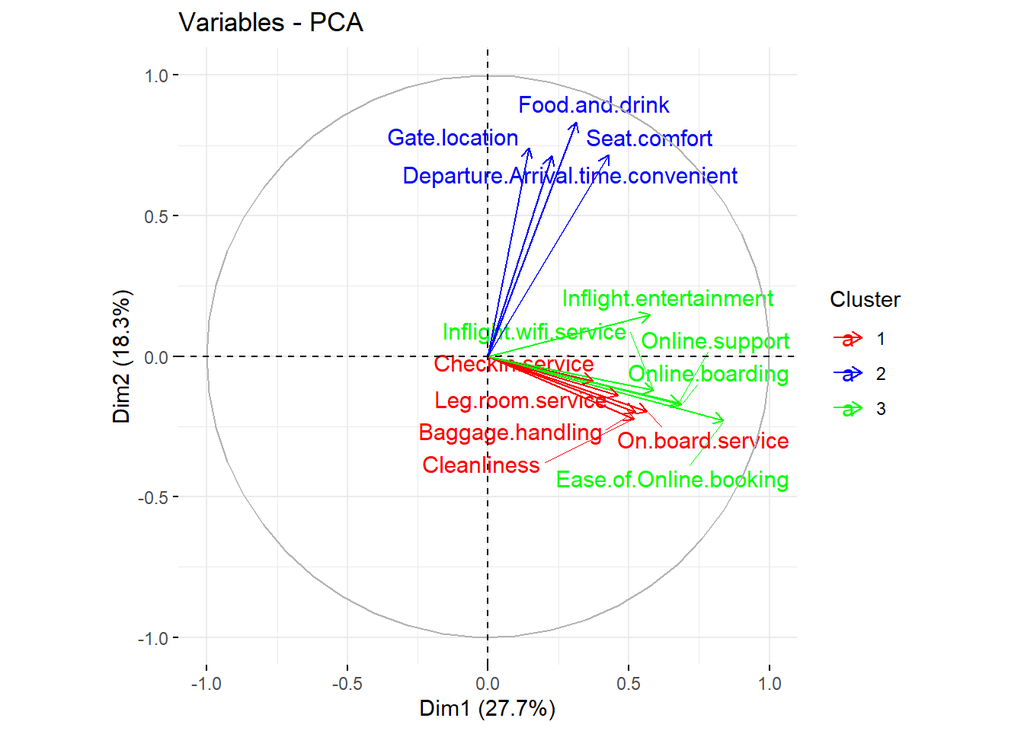

```r
# K-means clustering on PCA variable loadings
res.km = kmeans(var$coord, centers = 3, nstart = 25)
grp = as.factor(res.km$cluster)

# Visualize PCA with clusters
fviz_pca_var(pca, col.var = grp, palette = c("red", "blue", "green"), legend.title = "Cluster", repel = TRUE)
```

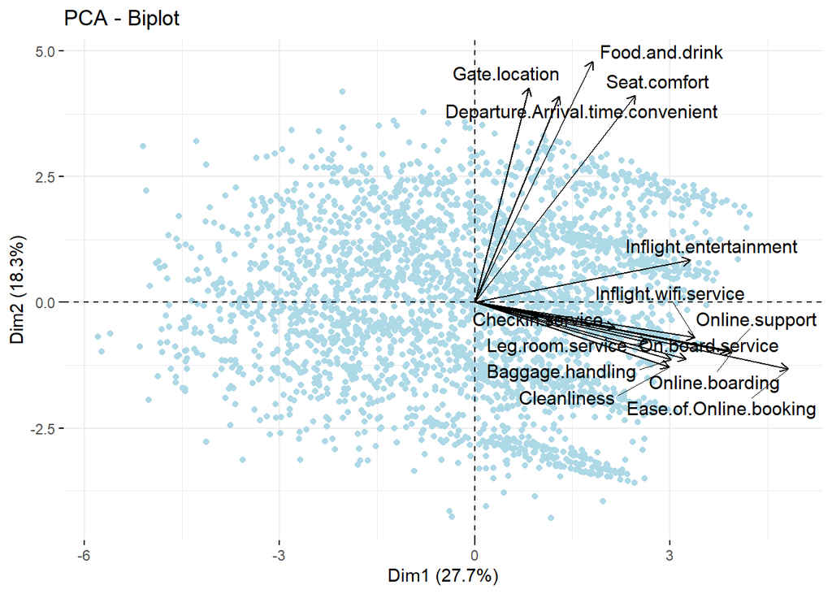

```r
# Biplot of individuals and variables
fviz_pca_biplot(pca, geom = "point", repel = TRUE, col.var = "black", col.ind = "lightblue")
```

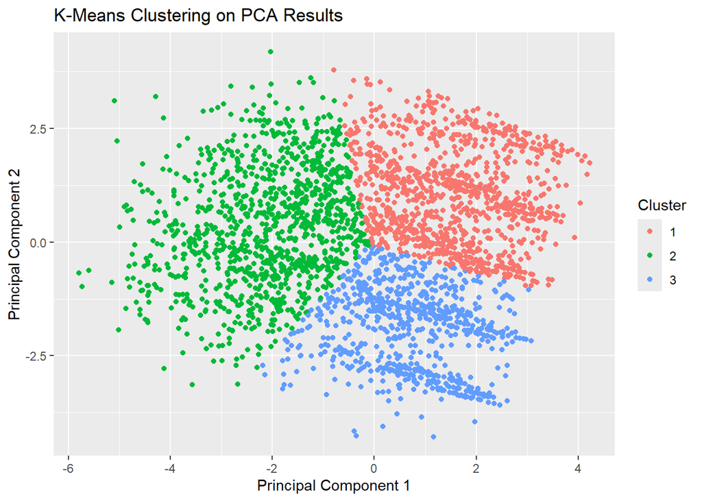

```r
# PCA results for individuals
pca_data = as.data.frame(pca$ind$coord)

# K-means clustering on individuals
set.seed(123)
kmeans_result = kmeans(pca_data[, 1:2], centers = 3, nstart = 25)
pca_data$Cluster = factor(kmeans_result$cluster)

# Visualize clusters
ggplot(pca_data, aes(x = Dim.1, y = Dim.2, color = Cluster)) + geom_point() + ggtitle("K-Means Clustering on PCA Results") + xlab("Principal Component 1") + ylab("Principal Component 2")
```

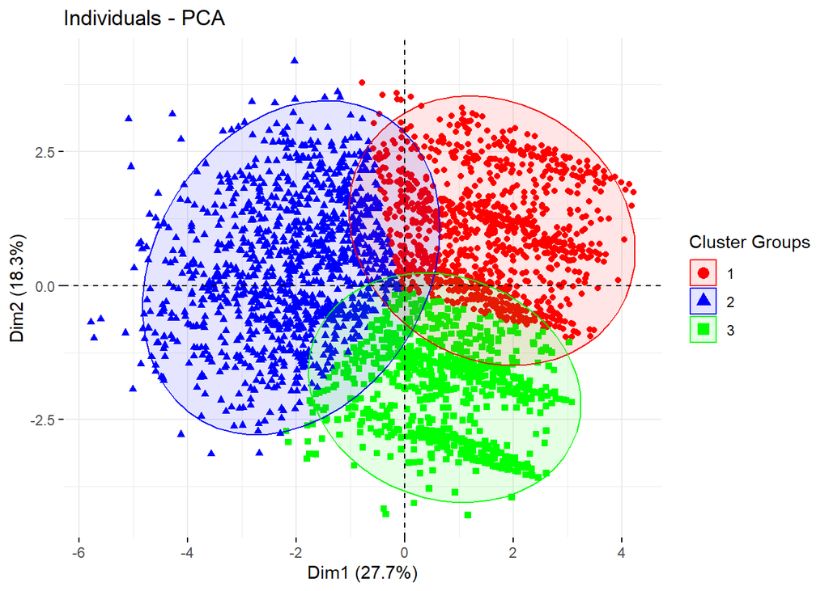

```r
# Visualize clustering with ellipses
fviz_pca_ind(pca, geom.ind = "point", col.ind = pca_data$Cluster, palette = c("red", "blue", "green"), addEllipses = TRUE, legend.title = "Cluster Groups")
```

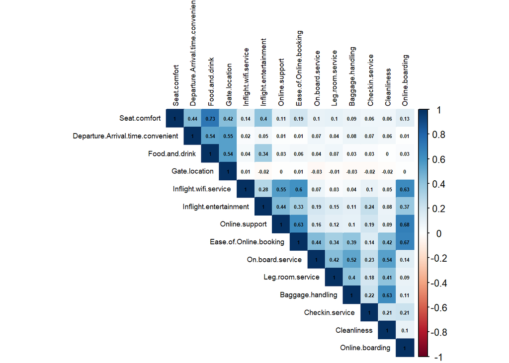

```r
# Correlation matrix
cor_matrix = cor(filtered_data)

# Correlation visualization
corrplot(cor_matrix, method = "color", type = "upper", tl.col = "black", tl.cex = 0.6, addCoef.col = "black", number.cex = .4)
```

```r
#################################################################################
# Exploratory Analysis
# 1. Which variables are most correlated with overall satisfaction?
var = get_pca_var(pca)
print(var$contrib)  # Contribution of variables
```

```
##                                        Dim.1      Dim.2        Dim.3
## Seat.comfort                       4.7425717 19.9705842  0.006721254
## Departure.Arrival.time.convenient  1.3087848 19.8066962  1.071045538
## Food.and.drink                     2.5423993 27.0688849  0.120692705
## Gate.location                      0.5354331 21.4398998  0.149174296
## Inflight.wifi.service              8.9152866  0.5685450 13.808641426
## Inflight.entertainment             8.5401049  0.8421010  2.485118817
## Online.support                    11.8467223  1.0655170 11.162378513
## Ease.of.Online.booking            18.0715968  2.0501810  0.889237864
## On.board.service                   8.2231876  1.5014677 12.718320621
## Leg.room.service                   5.4814886  0.7490788 10.687014387
## Baggage.handling                   7.0817202  1.5379233 16.645863940
## Checkin.service                    3.5974163  0.2928632  0.745373660
## Cleanliness                        6.9483036  1.9502278 17.128135586
## Online.boarding                   12.1649844  1.1560303 12.382281392
##                                         Dim.4        Dim.5
## Seat.comfort                       2.54571544 7.312106e+00
## Departure.Arrival.time.convenient  4.49919416 1.097767e+01
## Food.and.drink                     1.40303739 2.973322e+00
## Gate.location                     11.67600190 6.623137e+00
## Inflight.wifi.service              5.64769171 1.808260e-01
## Inflight.entertainment            33.32403840 9.782789e+00
## Online.support                     0.03811585 4.218131e-01
## Ease.of.Online.booking             6.55118314 1.088806e+00
## On.board.service                   0.00514779 3.607666e-01
## Leg.room.service                   0.27091112 2.680284e+00
## Baggage.handling                   0.80814583 4.367797e-03
## Checkin.service                   29.89099062 5.591416e+01
## Cleanliness                        2.18039117 5.988329e-04
## Online.boarding                    1.15943547 1.679357e+00
```

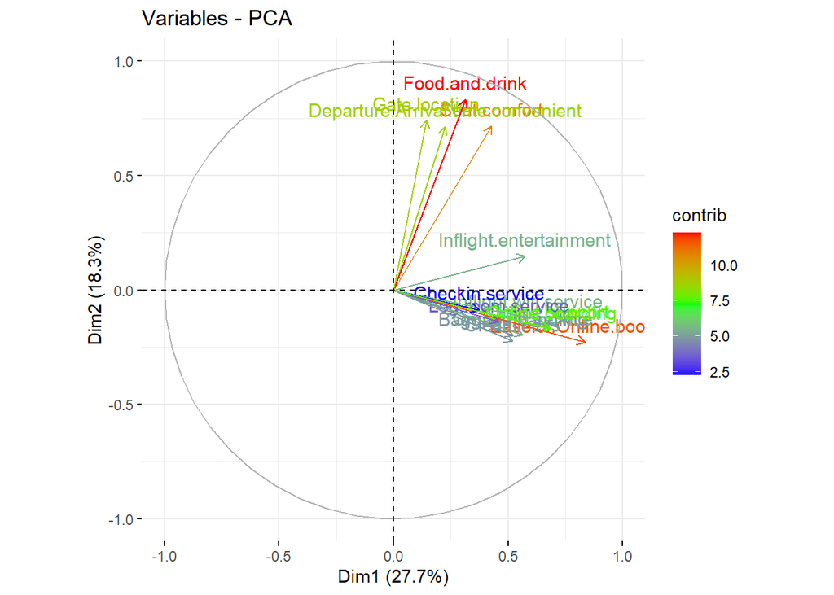

```r
fviz_pca_var(pca, col.var = "contrib", gradient.cols = c("blue", "green", "red"))
```

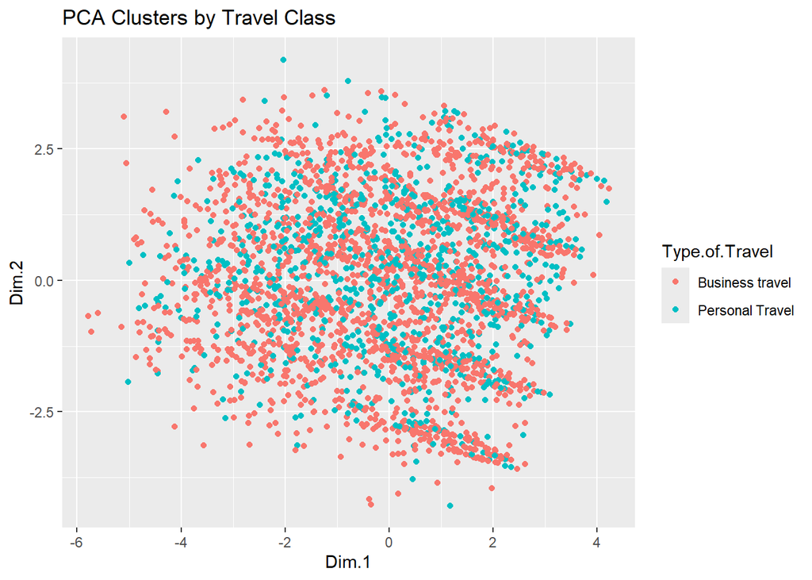

```r
# 2. How does travel class influence service perception?
pca_data$Type.of.Travel = airline_data$Type.of.Travel
ggplot(pca_data, aes(x = Dim.1, y = Dim.2, color = Type.of.Travel)) + geom_point() + ggtitle("PCA Clusters by Travel Class")
```

```r
#################################################################################
# Comparative Analysis
# 1. Are there significant differences in satisfaction between men and women?
# Convert the satisfaction column to binary 1 or 0 for satisfied or not
airline_data$satisfaction_binary = ifelse(airline_data$satisfaction == "satisfied", 1, 0)
t_test = t.test(satisfaction_binary ~ Gender, data = airline_data)
print(t.test)
```

[output not shown]

[output not shown]

```
## function (x, ...)
## UseMethod("t.test")
## <bytecode: 0x000002982edaa410>
## <environment: namespace:stats>
```

[figure not shown]

```r
# 2. How does satisfaction compare between domestic and international flights?
airline_data$satisfaction_binary = ifelse(airline_data$satisfaction == "satisfied", 1, 0)
ggplot(airline_data, aes(x = Type.of.Travel, fill = factor(satisfaction_binary))) + geom_bar(position = "fill") + scale_fill_manual(values = c("red", "green"), labels = c("Dissatisfied", "Satisfied")) + labs(x = "Flight Type", y = "Proportion", fill = "Satisfaction") + ggtitle("Satisfaction by Flight Type (Domestic vs International)") + theme_minimal()
```

## Cluster Analysis (Jack)

### 1. What groups of customers with similar characteristics can be identified?

This question can best be answered by conducting a cluster analysis. Given that we’ve done the preparation work and creation of our clusters earlier, we can reuse what we’ve already done and analyze once again.

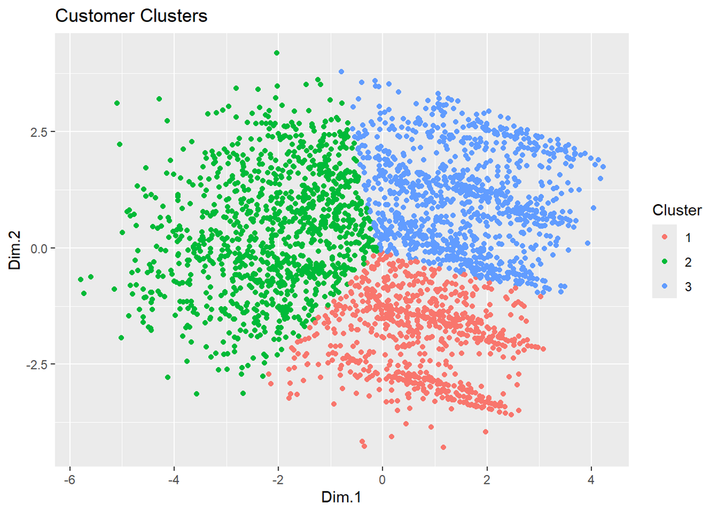

```r
# Recreating and visualizing our clusters

kmeans_result = kmeans(pca_data[, c("Dim.1", "Dim.2")], centers = 3, nstart = 25)
pca_data$Cluster = as.factor(kmeans_result$cluster)
ggplot(pca_data, aes(x = Dim.1, y = Dim.2, color = Cluster)) + geom_point() + ggtitle("Customer Clusters")
```

```r
# Add Cluster information to the original dataset
airline_data$Cluster <- pca_data$Cluster

# Summarizing the makeup of clusters
cluster_summary <- airline_data %>%
  group_by(Cluster) %>%
  summarise(across(where(is.numeric), mean, na.rm = TRUE))

print(cluster_summary)
```

```
## # A tibble: 3 × 20
##   Cluster   Age Flight.Distance Seat.comfort Departure.Arrival.time.convenient
##   <fct>   <dbl>           <dbl>        <dbl>                             <dbl>
## 1 1        40.1           2075.         1.79                              1.82
## 2 2        38.2           1998.         2.43                              2.79
## 3 3        40.5           1951.         3.98                              3.90
## # ℹ 15 more variables: Food.and.drink <dbl>, Gate.location <dbl>,
## #   Inflight.wifi.service <dbl>, Inflight.entertainment <dbl>,
## #   Online.support <dbl>, Ease.of.Online.booking <dbl>, On.board.service <dbl>,
## #   Leg.room.service <dbl>, Baggage.handling <dbl>, Checkin.service <dbl>,
## #   Cleanliness <dbl>, Online.boarding <dbl>, Departure.Delay.in.Minutes <dbl>,
## #   Arrival.Delay.in.Minutes <dbl>, satisfaction_binary <dbl>
```

Here we can see the three clusters that our data is split into, as well as the average demographic information of these customer clusters to better understand the group characteristics.

Our first cluster contains slightly longer distance flight customers with low seat comfort, flight departure/arrival time convenience, and food ratings. The second cluster is marked by low in-flight entertainment, online support, inflight wifi service, online booking ease, onboard service and legroom service ratings, among others. Most notably, this group has a very low satisfaction rating on average, which aligns with the other low ratings across the board. The thrid cluster is more similar to the first, except with higher inflight entertainment, seat comfort, food and drink, and departure/arrival time convenience ratings.

### 2. What are the main differences between satisfied and dissatisfied customer groups?

Upon looking at our cluster summary, it was clear that the second cluster was far less satisfied with their airline experience than the other two clusters. Let’s look at some of the key variables that underlie this satisfaction difference.

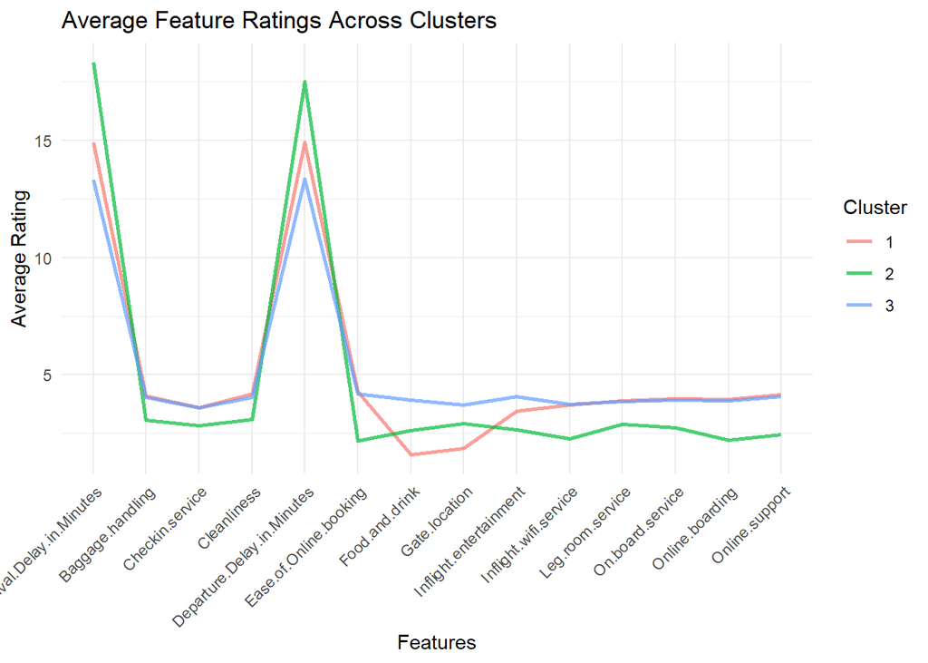

```r
# Selecting the relevant features from the dataset (determin)
features_for_comparison <- airline_data %>%
  select(Inflight.wifi.service, Inflight.entertainment, Online.support,
         Ease.of.Online.booking, On.board.service, Food.and.drink, Gate.location, Leg.room.service, Online.support,
         Baggage.handling, Checkin.service, Cleanliness, Online.boarding,
         Departure.Delay.in.Minutes, Arrival.Delay.in.Minutes, Cluster)

# Reshaping the data into a long format
features_long <- features_for_comparison %>%
  pivot_longer(cols = -Cluster, names_to = "Feature", values_to = "Rating")

# Computing the average rating for each feature and cluster once again
avg_features_by_cluster <- features_long %>%
  group_by(Cluster, Feature) %>%
  summarise(Avg_Rating = mean(Rating), .groups = "drop")

# Creating our parallel coordinate plot
ggplot(avg_features_by_cluster, aes(x = Feature, y = Avg_Rating, group = Cluster, color = factor(Cluster))) +
  geom_line(alpha = 0.7, size = 1) +
  labs(
    title = "Average Feature Ratings Across Clusters",
    x = "Features",
    y = "Average Rating",
    color = "Cluster"
  ) +
  theme_minimal() +
  theme(axis.text.x = element_text(angle = 45, hjust = 1)) # Rotate x-axis labels for readability
```

As we can now see visually, the second cluster consistently has much lower scores in almost all of the major in-flight accommodation ratings such as leg room and entertainment, as well as the online experience. It is also worth noting that these customers experienced delayed departures and arrivals more often than our satisifed customer clusters.

### 3. How does customer loyalty vary across clusters?

I’m curious to see the customer loyalty makeup of our clusters. I imagine the the second, mostly dissatisfied cluster will have a lower proportion of loyal customers, but I’m curious to see if our first and third clusters have any significant difference and what this may say about the groups in our data.

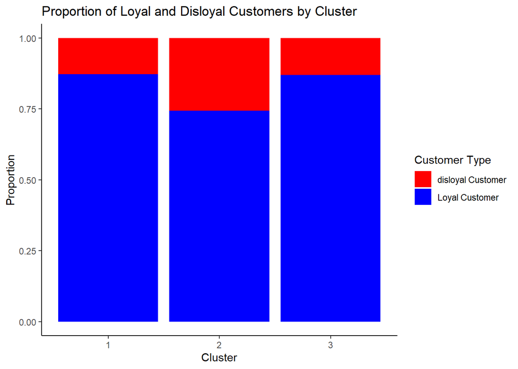

```r
# Stacked bar chart of Customer Loyalty by Cluster
ggplot(airline_data, aes(x = factor(Cluster), fill = Customer.Type)) +
  geom_bar(position = "fill") +  # "fill" normalizes to proportions
  labs(
    title = "Proportion of Loyal and Disloyal Customers by Cluster",
    x = "Cluster",
    y = "Proportion",
    fill = "Customer Type"
  ) +
  scale_fill_manual(values = c("Loyal Customer" = "blue", "disloyal Customer" = "red")) +
  theme_classic()
```

As we can observe here, our second cluster of mostly dissatisfied individuals is made up of a smaller proportion of loyal customers than our other two clusters. This was expected and aligns with our earlier findings. Our first and third clusters essentially have the same proportion of loyal and disloyal customers, meaning that there are no groups that have high satisfaction with low customer loyalty, proving the importance of this variable.

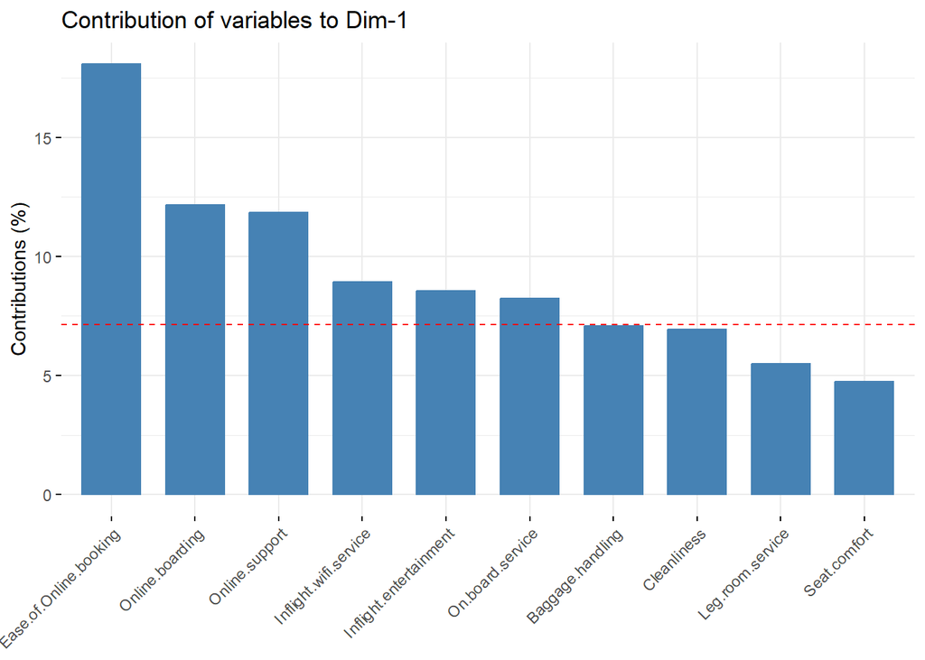

```r
#################################################################################
# Service-Specific Analysis
# 1. Which service has the most significant impact on satisfaction? (PC1)
fviz_contrib(pca, choice = "var", axes = 1, top = 10)
```

```r
# 2. What service improvements would have the greatest effect on satisfaction?
top_services = var$contrib[, 1]
print(sort(top_services, decreasing = TRUE))
```

```
##            Ease.of.Online.booking                   Online.boarding
##                        18.0715968                        12.1649844
##                    Online.support             Inflight.wifi.service
##                        11.8467223                         8.9152866
##            Inflight.entertainment                  On.board.service
##                         8.5401049                         8.2231876
##                  Baggage.handling                       Cleanliness
##                         7.0817202                         6.9483036
##                  Leg.room.service                      Seat.comfort
##                         5.4814886                         4.7425717
##                   Checkin.service                    Food.and.drink
##                         3.5974163                         2.5423993
## Departure.Arrival.time.convenient                     Gate.location
##                         1.3087848                         0.5354331
```

## Recommendation Analysis

### 1. Which customer groups should be the primary focus?

As we’ve seen already, loyal customers are far more satisfied than non-loyal customers on average, so we will need to convert these non-loyal customers by creating a better experience for them. Let’s take a look at some satisfaction levels for various customer demographics to determine where the focus of the company should be in the future.

```r
set.seed(451)
kmeans_model = kmeans(pca_data[, c("Dim.1", "Dim.2")], centers = 3)
pca_data$Cluster = as.factor(kmeans_model$cluster)
colnames(pca_data)
```

```
## [1] "Dim.1"          "Dim.2"          "Dim.3"          "Dim.4"
## [5] "Dim.5"          "Cluster"        "Type.of.Travel"
```

[figure not shown]

```r
ggplot(pca_data, aes(x = Dim.1, y = Dim.2, color = Cluster)) + geom_point() + facet_wrap( ~ Type.of.Travel) + ggtitle("Clusters by Satisfaction Level")
```

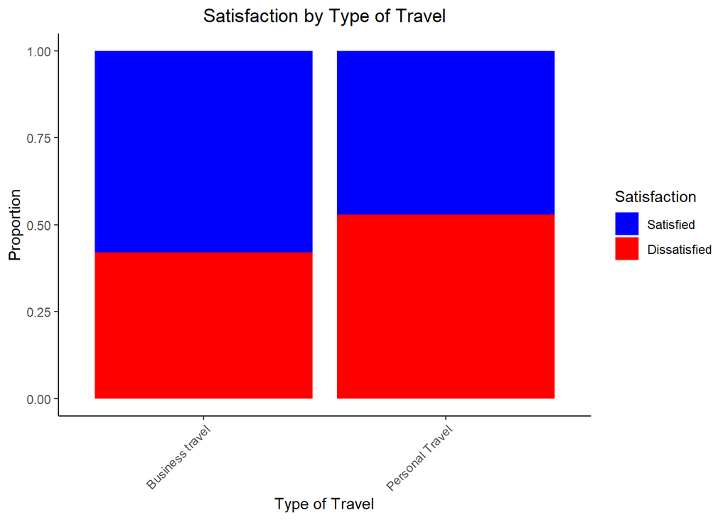

```r
# Visualizing satisfaction by type of travel
ggplot(airline_data, aes(x = Type.of.Travel, fill = satisfaction)) +
  geom_bar(position = "fill") +
  scale_fill_manual(
    values = c("satisfied" = "blue", "dissatisfied" = "red"),
    labels = c("Satisfied", "Dissatisfied")
  ) +
  labs(
    title = "Satisfaction by Type of Travel",
    x = "Type of Travel",
    y = "Proportion",
    fill = "Satisfaction"
  ) +
  theme_classic() +
  theme(
    axis.text.x = element_text(angle = 45, hjust = 1),
    plot.title = element_text(hjust = 0.5)
  )
```

As we can see, personal travelers are more often dissatisfied with their flight experience than business travelers, meaning that the company should prioritize first enhacing the experience of personal travelers.